# 計算論的アプローチ

## 国里愛彦（くにさと よしひこ）

- 専修大学人間科学部心理学科 教授
- 専門：計算論的精神医学、認知行動療法
- COI開示：国里の著書や関連する団体について紹介するが、特定企業との利益相反はない。

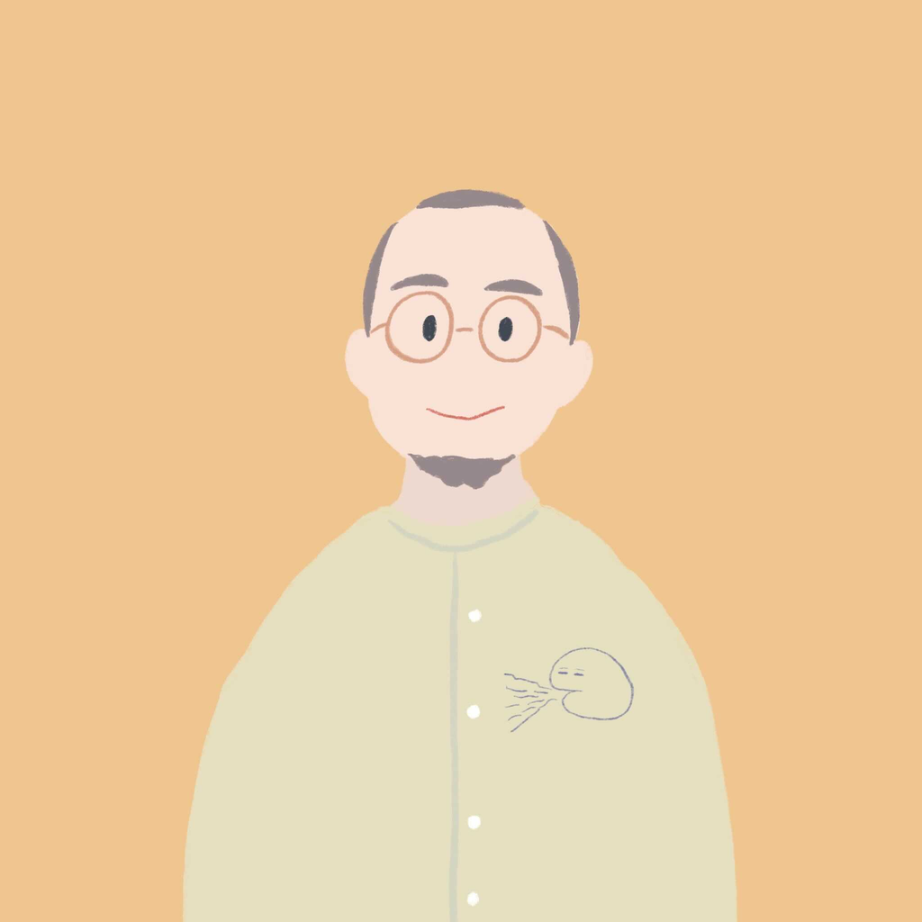

## 計算論的精神医学のはじまり

- 2010年代に、計算論的神経科学の精神医学への応用がはじまり、計算論的精神医学としてまとまる。
- 2011年くらいから複数の雑誌に計算論的精神医学に関する総説が掲載。 2016年には、『Computational Psychiatry』と題する書籍も出版。
- 精神障害に関連した神経・認知的現象の数理モデルの構築を目的とする学際的研究領域

## 日本での計算論的精神医学

- 2013年くらいから日本でも複数の総説論文が出版(山下, 松岡, and 谷 2013; 国里 2013)
- 2019年に[『計算論的精神医学』](https://www.keisoshobo.co.jp/book/b383336.html)が出版(国里愛彦・片平健太郎・沖村宰・山下祐一 2019)
- 2025年に[『R/Pythonではじめる計算論的精神医学』](https://www.kinpodo-pub.co.jp/book/2044-3/)が出版(宗田卓史 et al. 2025)

[figure not shown]

## [計算論的精神医学コロキウム](https://cpsycolloq.github.io/main/)

- 計算論的精神医学研究の推進を目的として2025年に社団法人化
- CPSY TOKOを毎年開催(今年度は第5回目を2027/2/18-19に開催予定)
- 2026年は、８月に「Claude Codeではじめる計算論的精神医学」を開催

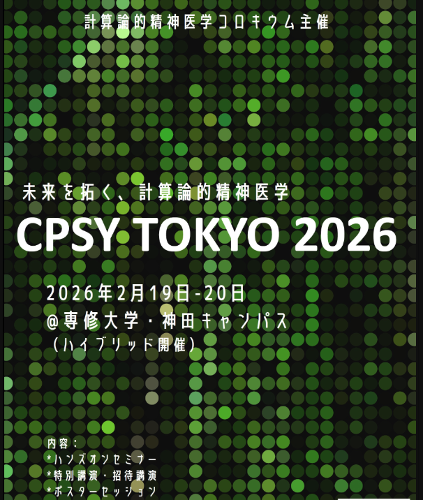

## 計算論的とは？

- 私達や動物の行動の背後にある計算過程を数式で表現したモデルを用いること。
- ここでの計算は意識的な計算に限定されず、脳内のあらゆる情報処理においてなされる無意識的な計算も含む。
- 計算論的神経科学や計算論的精神医学は、計算論的アプローチをとる。

## 計算論的精神医学の基本的枠組み

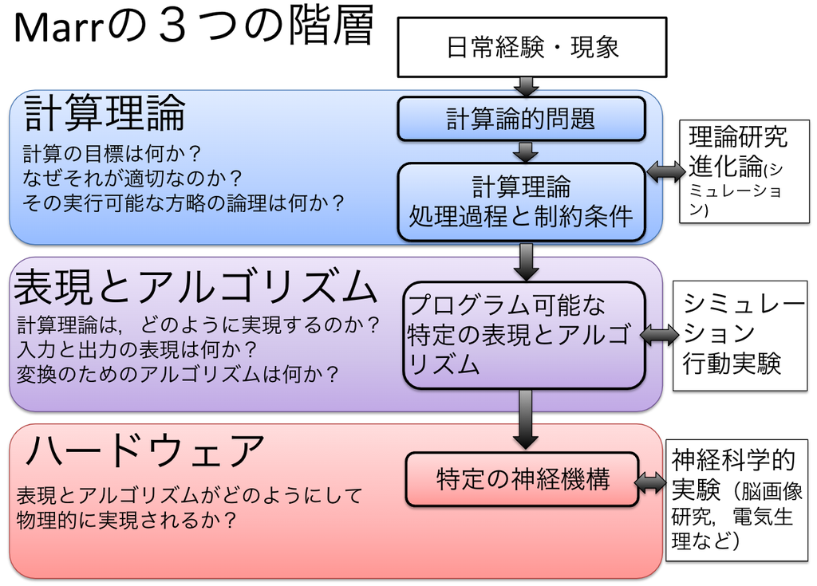

## ４つの生成モデル

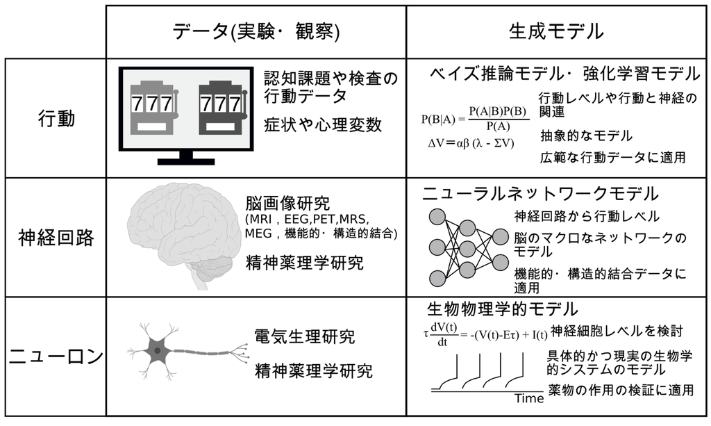

## 生成モデル、シミュレーション、パラメータ推定

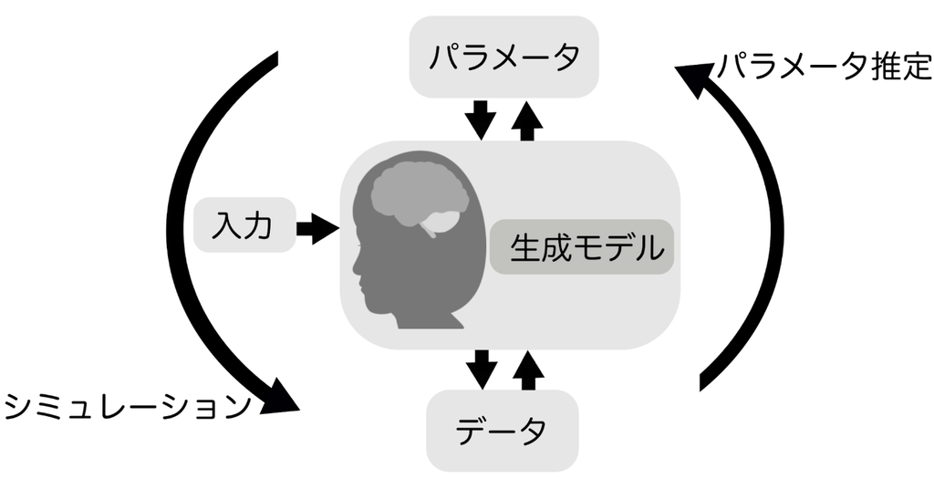

## 計算論的精神医学への期待

- **[理解]** 症状・行動の水準と生物学的水準との間の説明のギャップを埋める
- **[理論]** 自然言語で書かれたモデルの数理モデル化とその統合
- **[アセスメント]** 計算論的アプローチにより疾患マーカーの洗練化が期待される(計算論的表現型)
- **[シミュレーション]** 効果的な治療の探索や臨床的な経過の予想

## 強化学習モデル

- 「長期的にみて報酬を最大化するために，環境の状態に対して，特定の行動を学習するエージェントについての計算論的な枠組み」
- 環境との相互作用を通して行動が生成されるに至った内的なプロセスを少ないパラメータ数でモデル化でき，それらのパラメータと精神障害との関連を検討可能。

## Q learning Model(Watkins 1989)

- TD誤差が小さくなるようにQ値を更新することで，最適な行動価値関数を学習するモデル
- softmax関数と組みわせて行動選択モデルとして使い、学習率（学習の速度）や逆温度（より価値に沿った行動をする程度）がパラメータとして推定可能

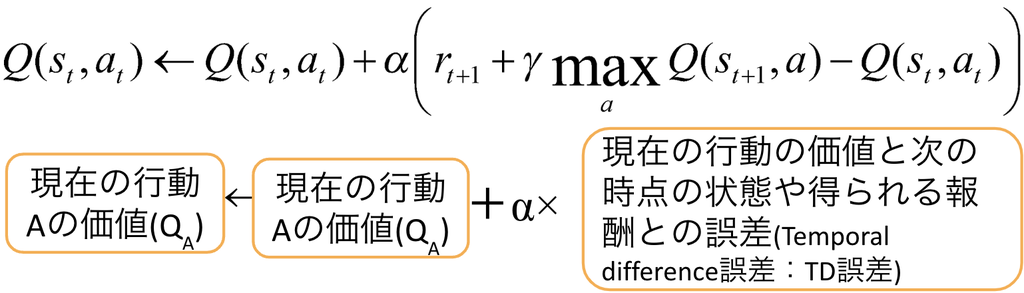

## うつと強化学習モデル

- Kunisato et al. (2012) は、抑うつが高いと行動レベルで報酬感受性が低下し、強化学習モデルにおける逆温度が低下する(選択のランダムさの増加)ことを報告
- Huys et al. (2012) も同様の研究を発表し、その後もうつと強化学習モデルの研究が行われる(私が気づいてなかっただけで、先に Chase et al. (2010) が同じ研究を実施)
- Pike and Robinson (2022) はメタ分析を実施し、逆温度は抑うつ・不安において低くなることを報告

→CBTによってどう変化するか？

## うつのCBT前後のパラメータ変化

- Brown et al. (2021) は、28名のうつ病患者にCBTを実施。CBTにより，(1)報酬学習の感受性(=逆温度)向上，アウトカムシフト(全体的な評価バイアス)が低下。(2)損失学習の学習率と感受性が低下。
- Huys et al. (2022) は、13名のうつ病患者に行動活性化を実施。BAの標的（報酬の追求と回避の低減）に関して、課題時のパラメータが治療反応を予測。

→パラメータはCBTによって変化し、治療反応を予測する可能性

## CBTのコンポーネントと強化学習

- Norbury et al. (2024) は、オンラインのクロスオーバー試験を実施（行動活性化、認知再構成）
- BAは報酬を獲得する際の努力に対する感受性を特異的に低下、CRはネガティブな出来事を自己に帰属させる傾向を特異的に低下

→CBTのコンポーネントとパラメータとの関係の検討

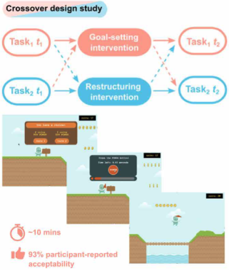

## 強化学習から自由エネルギー原理へ

- 計算論的精神医学の実証研究は強化学習モデルが牽引してきたが、環境の複雑さに対応する階層性をもった認知モデルの作成には限界がある

→ 生命や脳の統一的原理である自由エネルギー原理への関心が高まっている。

## 自由エネルギー原理

- 自由エネルギー原理は、フリストンらによって提唱されたベイズ推論モデルをベースにした脳と心の統一的理論
- 感覚入力$o$の背後に、それを生み出した直接観測できない外部状態 $s^*$ がある
- 感覚入力$o$から外部状態 $s^*$ を推論する

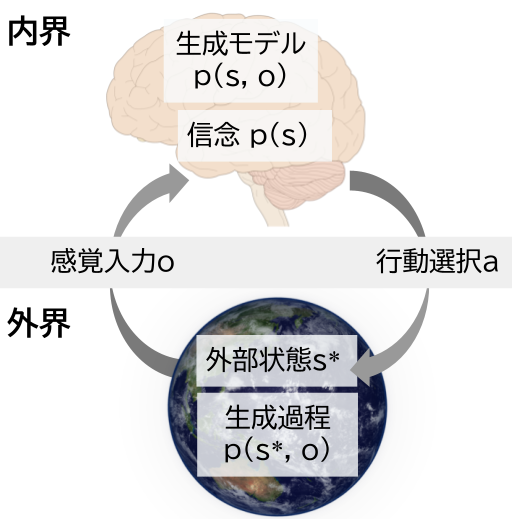

## 生成モデルとベイズ更新

- 内部状態sと感覚入力$o$の同時確率分布(生成モデル)を用いて外部状態を推論
- 感覚入力$o$から内部状態の信念$p(s)$をベイズ更新(事前信念を尤度で更新)=知覚推論（変分自由エネルギー最小化）
- 信念に基づく外界の状態への働きかけ$a$=能動的推論（期待自由エネルギー最小化）

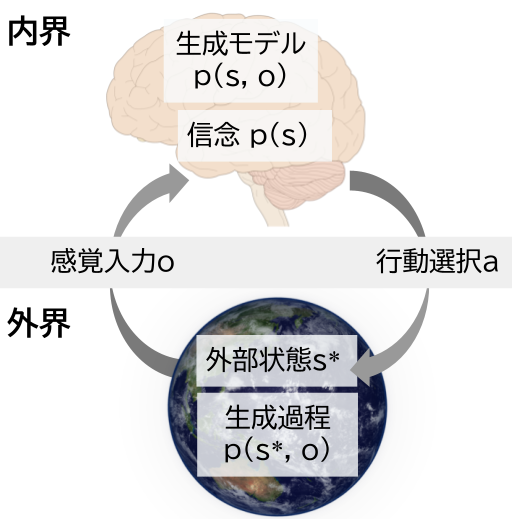

## 自由エネルギー原理と心理療法

- CBTの非機能的認知は，世界のモデルについての事前信念として捉えられる(Moutoussis et al. 2018)
- **精神分析**の防衛，**認知療法**の中核的信念，**行動分析**の不適応な行動パターンは、事前信念から整理できる(Krupnik 2019)。事前信念の変容には高い精度の予測誤差を導入する必要がある
- **マインドフルネス**は行為推論→知覚推論を促す実践であり，予測誤差への精度を高め，事前信念の更新を促す(Manjaly and Iglesias 2020; 国里 and 山本 2021)

## クモ恐怖のCBTのシミュレーション

- Smith, Moutoussis, and Bilek (2021) は，クモ恐怖のCBTモデルから能動的推論シミュレーション
- 認知再構成で「クモは安全」という信念獲得後に曝露すると，顕在信念は安全と判断するが，潜在信念(クモへの接近とポジティブ感情との関連)に変化なし(クモ危険信念が強くも弱くもない状態の曝露は潜在信念低下）

→ 不確実な顕在信念下での曝露が良い？

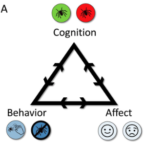

## 社交不安のCBTのシミュレーション

- Zhang et al. (2025) は，HofmannのCBTモデルを能動的推論モデル化
- 低い自己効力感と社会的損失の過大視が回避行動を誘発する
- 自己注目傾向が高いと信念更新も行動選択も阻害され、反芻は否定的な出来事後の信念をより悪化させた

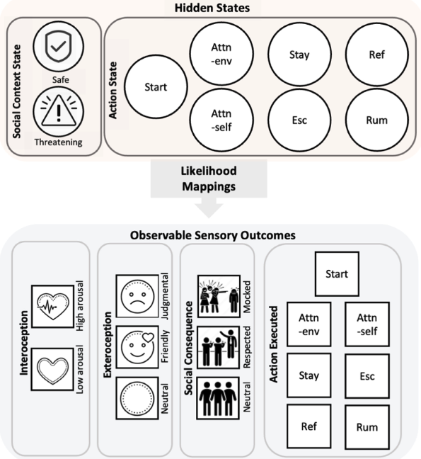

→能動的推論モデルは認知行動モデルの組み込みが可能。実証データでのパラメータ推定も。

## 心理ネットワークとの合流

- 計算論的精神医学と独立に、変数間のネットワーク構造を検討する心理ネットワークアプローチが展開。
- うつ病の横断データから症状ネットワークを推定し、時間的挙動のシミュレーションもできる(Cramer et al. 2016)

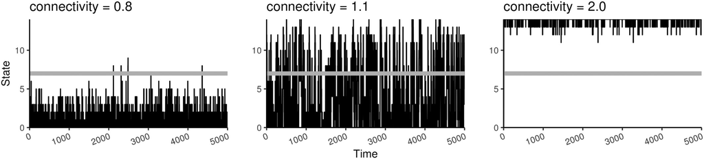

## 介入シミュレーション

- ネットワークから治療的な要素を追加する介入シミュレーションもできる(Omizu and Kunisato 2024)

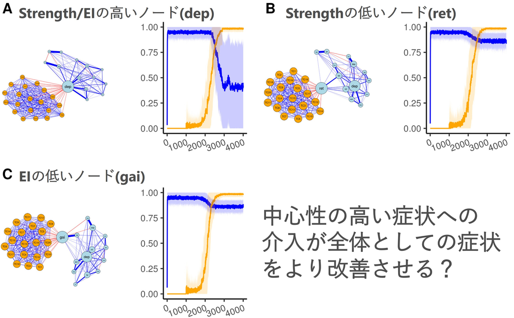

## 理論駆動とデータ駆動

- 計算論的精神医学は理論駆動的なアプローチだが、機械学習のデータ駆動アプローチと組み合わせることが有効
- 物理学の発展も理論に基づく研究、データ駆動アプローチがきて、最近は理論駆動とデータ駆動の両面が行われている。
- シミュレーションベース推論(SBI)やシステム同定の手法など、複雑なモデルによるシミュレーションとデータをつなぐツールも出てきている（流体力学や気象学が参考になる）

## 能動的推論を共通言語に

- 認知行動療法モデルを、信念・症状・行動が時間のなかで相互作用する**動的な生成モデル**として形式化する。
1. **シミュレーション**：症状の発生・維持過程を再現する
2. **介入シミュレーション**：CBTの構成要素を操作し、変化や効果を比較する
3. **パラメータ推定**：実証データから個人差や治療による変化を捉える

→ 共通言語として能動的推論を使えるのではないか？

## まとめ

- 強化学習モデルは、データを用いたパラメータ推定がなされてきた。実証研究としては現実的な選択肢になる。
- ベイズ推論モデルは、信念の更新過程を扱え、柔軟なモデル化も可能。現状ではシミュレーション研究が中心だが、今後の展開が期待できる

→ **9/6(日)13:40-15:20**に[TWS「Pythonによる能動的推論入門」](https://pub.confit.atlas.jp/ja/event/jpa2026/presentation/qP-C7dQT-01)を行います！

- 数理モデルを用いて認知行動療法を見つめ直そう！

## 引用文献

Brown, Vanessa M, Lusha Zhu, Alec Solway, John M Wang, Katherine L McCurry, Brooks King-Casas, and Pearl H Chiu. 2021. “Reinforcement Learning Disruptions in Individuals with Depression and Sensitivity to Symptom Change Following Cognitive Behavioral Therapy.” *JAMA Psychiatry (Chicago, Ill.)* 78 (10): 1113–22.

Chase, H W, M J Frank, A Michael, E T Bullmore, B J Sahakian, and T W Robbins. 2010. “Approach and Avoidance Learning in Patients with Major Depression and Healthy Controls: Relation to Anhedonia.” *Psychological Medicine* 40 (3): 433–40.

Cramer, Angélique O J, Claudia D van Borkulo, Erik J Giltay, Han L J van der Maas, Kenneth S Kendler, Marten Scheffer, and Denny Borsboom. 2016. “Major Depression as a Complex Dynamic System.” *PloS One* 11 (12): e0167490.

Huys, Quentin J M, Neir Eshel, Elizabeth O’Nions, Luke Sheridan, Peter Dayan, and Jonathan P Roiser. 2012. “Bonsai Trees in Your Head: How the Pavlovian System Sculpts Goal-Directed Choices by Pruning Decision Trees.” *PLoS Computational Biology* 8 (3): e1002410.

Huys, Quentin J M, Evan M Russek, George Abitante, Thorsten Kahnt, and Jacqueline K Gollan. 2022. “Components of Behavioral Activation Therapy for Depression Engage Specific Reinforcement Learning Mechanisms in a Pilot Study.” *Computational Psychiatry (Cambridge, Mass.)* 6 (1): 238–55.

Krupnik, Valery. 2019. “Bayesian Approach to Psychotherapy Integration: Strategic Modification of Priors.” *Frontiers in Psychology* 10 (February): 356.

Kunisato, Yoshihiko, Yasumasa Okamoto, Kazutaka Ueda, Keiichi Onoda, Go Okada, Shinpei Yoshimura, Shin-Ichi Suzuki, Kazuyuki Samejima, and Shigeto Yamawaki. 2012. “Effects of Depression on Reward-Based Decision Making and Variability of Action in Probabilistic Learning.” *Journal of Behavior Therapy and Experimental Psychiatry* 43 (4): 1088–94.

Manjaly, Zina-Mary, and Sandra Iglesias. 2020. “A Computational Theory of Mindfulness Based Cognitive Therapy from the ‘Bayesian Brain’ Perspective.” *Frontiers in Psychiatry / Frontiers Research Foundation* 11 (May): 404.

Moutoussis, Michael, Nitzan Shahar, Tobias U Hauser, and Raymond J Dolan. 2018. “Computation in Psychotherapy, or How Computational Psychiatry Can Aid Learning-Based Psychological Therapies.” *Computational Psychiatry (Cambridge, Mass.)* 2 (February): 50–73.

Norbury, Agnes, Tobias U Hauser, Stephen M Fleming, Raymond J Dolan, and Quentin J M Huys. 2024. “Different Components of Cognitive-Behavioral Therapy Affect Specific Cognitive Mechanisms.” *Science Advances* 10 (13): eadk3222.

Omizu, Takumi, and Yoshihiko Kunisato. 2024. “Exploring Effective Intervention Strategies for Depression as a Complex System: Targeted Interventions Through Network Simulations.” *The Japanese Psychological Research* 67 (2): 147–61.

Pike, Alexandra C, and Oliver J Robinson. 2022. “Reinforcement Learning in Patients with Mood and Anxiety Disorders Vs Control Individuals: A Systematic Review and Meta-Analysis: A Systematic Review and Meta-Analysis.” *JAMA Psychiatry* 79 (4): 313–22.

Smith, Ryan, Michael Moutoussis, and Edda Bilek. 2021. “Simulating the Computational Mechanisms of Cognitive and Behavioral Psychotherapeutic Interventions: Insights from Active Inference.” *Scientific Reports* 11 (1): 10128.

Watkins, Christopher John Cornish Hellaby. 1989. “Learning from Delayed Rewards.” PhD thesis, King’s College, University of Cambridge. http://www.cs.rhul.ac.uk/~chrisw/new_thesis.pdf.

Zhang, Yinghao, Friederike Elisabeth Hedley, Ru-Yuan Zhang, and Jingwen Jin. 2025. “Toward Quantitative Cognitive-Behavioral Modeling of Psychopathology: An Active Inference Account of Social Anxiety Disorder.” *Journal of Psychopathology and Clinical Science* 134 (4): 363–88.

国里愛彦. 2013. “うつとストレスに対する計算論的アプローチ : 計算論的精神医学入門.” *ストレス科学 = The Japanese Journal of Stress Sciences : 日本ストレス学会誌* 28 (2): 101–7.

国里愛彦, and 山本哲也. 2021. “マインドフルネス研究の未来を切り開く新たな方法論.” *心理学評論* 64 (4): 599–618.

国里愛彦・片平健太郎・沖村宰・山下祐一. 2019. *計算論的精神医学：情報処理過程から読み解く精神障害*. 勁草書房.

宗田卓史, 遠山朝子, 国里愛彦, 沖村宰, 片平健太郎, and 山下祐一. 2025. *R/Pythonではじめる計算論的精神医学*. 京都: 金芳堂.

山下祐一, 松岡洋夫, and 谷淳. 2013. “計算論的精神医学の可能性: 適応行動の代償としての統合失調症.” *精神医学* 55 (9): 885–95.